# SimpleMating: A R package to breeding crosses optimization

Marco Antonio Peixoto

2024-12-02

## Introduction

**SimpleMating** is a two-module package for cross-optimization. First, it estimates the performance for a set of crosses, such as mean parental average, cross total genetic value, and/or usefulness (using additive and/or non-additive effects), allowing for multi-trait scenarios. Furthermore, it uses a mate allocation algorithm to create a mating plan aiming to maximize a target criterion (mean parental average, total genetic value, or usefulness) and constrains the next generation’s inbreeding levels.

In this tutorial, we will explain the implementation of both modules while connecting it with examples using the data from the package.

## Input files

Four files are needed but not all required, to run analyses in **SimpleMating**:

1. Matrix with markers from the parental population;
2. Marker effects for the target trait (or traits);
3. Genetic map for recombination frequency estimation or linkage disequilibrium matrix;
4. relationship matrix (pedigree- or marker-based).

```r
# 1. Install and require the package
# install.packages(SimpleMating)
require(SimpleMating)
```

#### 1) Marker matrix

The marker matrix has the information of genotypes (100 genotypes) in the lines and the information of SNPs in the columns, coded as 0,1,2 meaning the number of copies of the alternate allele presented for each loci.

```r
# Marker matrix
data(lines_Geno)
lines_Geno[1:5, 1:5]
```

```
#>    Chr1_SNP1 Chr1_SNP2 Chr1_SNP3 Chr1_SNP4 Chr1_SNP5
#> G1         0         0         2         0         2
#> G2         0         0         2         0         0
#> G3         0         0         2         0         2
#> G4         0         0         2         0         0
#> G5         0         0         2         0         0
```

#### 2) Marker effects

This is a data frame with the information on the effects for each marker from the matrix before mentioned for the trait under evaluation. In this case, each row represents one marker and each column one trait (two traits and 1230 markers).

```r
# Marker Effects
data(lines_addEffects)
head(lines_addEffects)
```

```
#>      add_trait1    add_trait2
#> 1  0.0207632801  1.034444e-03
#> 2 -0.0018488022 -7.234415e-03
#> 3 -0.0073807532  2.244785e-03
#> 4 -0.0066209813  2.713244e-03
#> 5  0.0004828055 -3.478676e-05
#> 6 -0.0204069302  1.191772e-02
```

#### 3) Genetic map

The genetic map is a data frame with the markers’ position information in the genome. There are three columns in the file, being the first the chromosome, the second represents the actual position of the marker (in centimorgan), and the third is the marker name. **SimpleMating** also allows the use of a linkage disequilibrium matrix for recombination instead of the genetic map. We discuss this below and give more details in the main paper.

```r
# Genetic Map
data(lines_GenMap)
head(lines_GenMap)
```

```
#>   chr         pos  mkr
#> 1   1  0.07865088  1_2
#> 2   1  3.64901989 1_11
#> 3   1  6.60301305 1_20
#> 4   1  7.04754570 1_22
#> 5   1  9.34700329 1_27
#> 6   1 11.35608253 1_33
```

#### 4) Relationship matrix

For the optimization itself, to restrict inbreeding levels, we need a relationship matrix. It could be a numerator relationship matrix based on pedigree data or a realized relationship matrix based on markers. Make sure that your relationship matrix contains the names of the individual’s genotypes as columns and row names.

## Examples

We going to cover seven examples of implementation, as follows:

1. Optimization based on usefulness for one additive trait using molecular markers. shortcut
2. Optimization based on usefulness for two additive traits using molecular markers. shortcut
3. Optimization based on usefulness for one additive/dominance trait using molecular markers. shortcut
4. Optimization based on total genetic value for one additive/dominance trait using molecular markers. shortcut
5. Optimization based on the mid-parental value for one additive trait using pedigree information. shortcut
6. Optimization: Using the linkage disequilibrium to predict the cross variance. shortcut
7. Thinning by relatedness: How to increase prediction speed. shortcut

## Optimization: Usefulness on additive trait

Here, we will create a mating plan based on the usefulness of one additive trait.

First, we create a crossing plan. The user may inform their own or use the function `planCross()` to create the crossing plan. The parents are all individuals genotyped and the information of their names should go in the argument *TargetPop*. We may choose which mate design we want (*MateDesign*). The upcoming step is to use the function `getUsefA()` to predict the usefulness of each cross in the crossing plan, using the markers, markers’ effects, and the genetic map. For this function, we may set the proportion of selection individuals (*proSel*), the population type (*Type*), and the generation (*Generation*).

```r
require(SimpleMating)

# 1. Assigning the parents
Parents <- rownames(lines_Geno)

# 2. Creating the crossing plan
Cross_plan <- planCross(TargetPop = Parents,
                        MateDesign = "half")
```

```
#> Number of crosses generated: 4950
```

```r
# 3. Creating a relationship matrix based on markers
relMat <- (lines_Geno %*% t(lines_Geno)) / ncol(lines_Geno)

# 4.  Usefulness of trait number 1 (DH)
usef_add <- getUsefA(MatePlan = Cross_plan,
                     Markers = lines_Geno,
                     addEff = lines_addEffects[, 1],
                     Map.In = lines_GenMap,
                     K = relMat,
                     propSel = 0.05,
                     Type = "DH",
                     Generation = 1)
```

```
#> Usefulness predicted for 4950 crosses.
```

```r
head(usef_add[[1]], 10)
```

```
#>    Cross.ID Parent1 Parent2    Mean  Variance        sd Usefulness
#> 1     G1_G2      G1      G2 4.51880 0.1333033 0.3651072    5.27191
#> 2     G2_G3      G2      G3 4.01124 0.3056290 0.5528372    5.15158
#> 3     G2_G4      G2      G4 4.18298 0.2135113 0.4620728    5.13610
#> 4     G1_G3      G1      G3 4.10644 0.2235912 0.4728543    5.08180
#> 5     G1_G4      G1      G4 4.27818 0.1284029 0.3583335    5.01732
#> 6     G3_G4      G3      G4 3.77061 0.3159532 0.5620971    4.93005
#> 7     G2_G5      G2      G5 3.38943 0.3341835 0.5780861    4.58186
#> 8     G1_G5      G1      G5 3.48462 0.2635954 0.5134154    4.54365
#> 9    G1_G30      G1     G30 3.40499 0.2795036 0.5286810    4.49551
#> 10   G1_G24      G1     G24 3.09747 0.4479298 0.6692756    4.47799
```

```r
head(usef_add[[2]], 10)
```

```
#>    Parent1 Parent2       Y         K
#> 1       G1      G2 5.27191 1.2292683
#> 2       G2      G3 5.15158 0.9886179
#> 3       G2      G4 5.13610 1.2162602
#> 4       G1      G3 5.08180 1.0569106
#> 5       G1      G4 5.01732 1.2227642
#> 6       G3      G4 4.93005 0.9821138
#> 7       G2      G5 4.58186 1.0373984
#> 8       G1      G5 4.54365 1.0373984
#> 9       G1     G30 4.49551 1.0796748
#> 10      G1     G24 4.47799 1.0243902
```

The second part uses a criterion for each cross (usefulness in this example) with a relationship matrix (based on markers in this example) and creates an optimum cross-selection-based mating plan. The idea is to restrict the levels of inbreeding, using the covariance in the individual-cross level, and maximize the criterion used (usefulness in this example). There is needed to set the target number of crosses in the mating plan (*n.cross*), with the maximum and minimum number of crosses that each parent can be part of (*max.cross* and *min.cross*), together with the level of covariance between cross via relationship matrix for the restriction (*culling.pairwise.k*).

The output will be the mating plan based on the parameters before mentioned.

```r
# 1. Creating the mating plan
maxGainPlan <- selectCrosses(data = usef_add[[2]],
                             n.cross = 10,
                             max.cross = 2,
                             min.cross = 1,
                             culling.pairwise.k = 1)

# Crosses parameters
maxGainPlan[[1]]
```

```
#>   culling.pairwise.k target.Y  target.K
#> 1                  1 3.870613 0.9710569
```

```r
# Mating Plan
maxGainPlan[[2]]
```

```
#>    Parent1 Parent2       Y         K
#> 1       G2      G3 5.15158 0.9886179
#> 2       G3      G4 4.93005 0.9821138
#> 3       G1     G13 4.33268 0.9788618
#> 4       G2     G24 4.32874 0.9918699
#> 5       G4     G24 4.23663 0.9463415
#> 6       G1     G10 4.19402 0.9658537
#> 7      G30     G98 2.92482 0.9528455
#> 8       G5     G56 2.92043 0.9788618
#> 9      G14     G30 2.90544 0.9495935
#> 10      G5     G54 2.78174 0.9756098
```

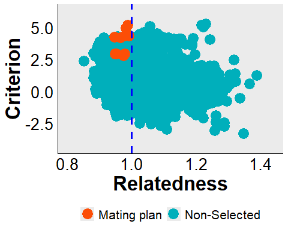

```r
# Plot
maxGainPlan[[3]]
```

## Optimization: Usefulness on Multi traits scenario

Here, we will create a mating plan based on the usefulness of two additive traits.

We need the crossing plan, with all individual candidates to be parents. We may use the function `planCross()` for doing so. The parents are all individuals genotyped (*TargetPop*). We may choose which mate design we want (*MateDesign*). The upcoming step is to use the function `getUsefA_mt()` to predict the usefulness of each cross in the cross plan, using the markers, markers’ effects, and the genetic map. In addition, we need to set weights for each trait (*Weights*), in a way to build a trait-based index for the estimation of usefulness. For this function, we may set the proportion of selection individuals (*proSel*), the population type (*Type*), and the generation (*Generation*).

```r
require(SimpleMating)

# 1. Assigning the parents
Parents <- rownames(lines_Geno)

# 2. Creating the crossing plan
Cross_plan <- planCross(TargetPop = Parents,
                        MateDesign = "half")
```

```
#> Number of crosses generated: 4950
```

```r
# 3. Creating a relationship matrix based on markers
relMat <- (lines_Geno %*% t(lines_Geno)) / ncol(lines_Geno)

# 4.  Usefulness for two traits
Multitrait_usef <- getUsefA_mt(MatePlan = Cross_plan,
                               Markers = lines_Geno,
                               addEff = lines_addEffects,
                               Map.In = lines_GenMap,
                               K = relMat,
                               propSel = 0.05,
                               Type = "RIL",
                               Generation = 1,
                               Weights = c(0.4, 0.6))
```

```
#> Usefulness predicted for 4950 crosses.
```

```r
head(Multitrait_usef[[1]], 10)
```

```
#>    Cross.ID Parent1 Parent2    Mean   Variance        sd Usefulness
#> 1     G1_G2      G1      G2 2.28678 0.01126616 0.1061422    2.50572
#> 2     G2_G4      G2      G4 2.24444 0.01504070 0.1226405    2.49741
#> 3     G1_G4      G1      G4 2.24372 0.01100678 0.1049132    2.46013
#> 4     G2_G3      G2      G3 1.85493 0.03397417 0.1843208    2.23513
#> 5     G3_G4      G3      G4 1.81186 0.03789793 0.1946739    2.21342
#> 6     G1_G3      G1      G3 1.85421 0.02578186 0.1605673    2.18541
#> 7     G2_G5      G2      G5 1.77789 0.02448657 0.1564819    2.10067
#> 8     G1_G5      G1      G5 1.77717 0.02014957 0.1419492    2.06997
#> 9    G2_G12      G2     G12 1.71979 0.02859541 0.1691018    2.06860
#> 10   G2_G30      G2     G30 1.68297 0.03234579 0.1798494    2.05395
```

```r
head(Multitrait_usef[[2]], 10)
```

```
#>    Parent1 Parent2       Y         K
#> 1       G1      G2 2.50572 1.2292683
#> 2       G2      G4 2.49741 1.2162602
#> 3       G1      G4 2.46013 1.2227642
#> 4       G2      G3 2.23513 0.9886179
#> 5       G3      G4 2.21342 0.9821138
#> 6       G1      G3 2.18541 1.0569106
#> 7       G2      G5 2.10067 1.0373984
#> 8       G1      G5 2.06997 1.0373984
#> 9       G2     G12 2.06860 1.0081301
#> 10      G2     G30 2.05395 1.0471545
```

The second part uses a criterion for each cross (usefulness in this example) with a relationship matrix (based on markers in this example) and creates an optimum cross-selection-based mating plan. The idea is to restrict the levels of inbreeding, using the covariance in the individual-cross level, and maximize the criterion used (usefulness in this example). There is needed to set the target number of crosses in the mating plan (*n.cross*), with the maximum and minimum number of crosses that each parent can be part of (*max.cross* and *min.cross*), together with the level of covariance between cross via relationship matrix for the restriction (*culling.pairwise.k*).

The output will be the mating plan based on the parameters before mentioned.

```r
# 1. Cross selection
maxGainPlan <- selectCrosses(data = Multitrait_usef[[2]],
                             n.cross = 10,
                             max.cross = 3,
                             min.cross = 1,
                             culling.pairwise.k = 1)

# Crosses parameters
maxGainPlan[[1]]
```

```
#>   culling.pairwise.k target.Y  target.K
#> 1                  1  1.92347 0.9785366
```

```r
# Mating Plan
head(maxGainPlan[[2]], 10)
```

```
#>    Parent1 Parent2       Y         K
#> 1       G2      G3 2.23513 0.9886179
#> 2       G3      G4 2.21342 0.9821138
#> 3       G4     G12 2.04633 0.9886179
#> 4       G4      G6 1.99178 0.9691057
#> 5       G2     G13 1.90305 0.9560976
#> 6       G1     G13 1.88016 0.9788618
#> 7       G2     G37 1.81394 0.9365854
#> 8       G3      G5 1.71879 0.9918699
#> 9       G1     G27 1.71851 0.9983740
#> 10      G1     G71 1.71359 0.9951220
```

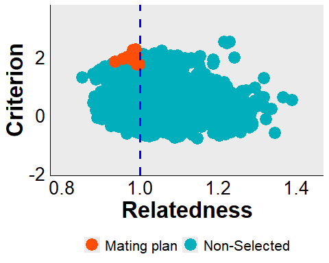

```r
# Plot
maxGainPlan[[3]]
```

## Optimization: Usefulness and additive/non-additive effects

Here, we will create a mating plan based on the usefulness of a trait with additive and dominance effects.

We need the crossing plan, with all individual candidates to parents. We may use the function `planCross()` for doing so. The parents are all individuals genotyped (*TargetPop*). We may choose which mate design we want (*MateDesign*). The upcoming step is to use the function `getUsefAD()` to predict the usefulness of each cross in the cross plan, using the markers, markers’ effects (additive marker effects and dominance marker effects), and the genetic map. For this function, we may set the proportion of selection individuals (*proSel*), the population type (*Type*), and the generation (*Generation*).

There are two options for the prediction of usefulness implemented in **SimpleMating**. One is based on phased haplotypes (a marker set where we know from each chromosome the copy of the allele came from) (*Method = Phased*). The method is a proposition that we implemented to estimate the usefulness without the need for phased haplotypes (*Method = NonPhased*).

```r
require(SimpleMating)

# 1. Loading the data
data(generic_GenMap)
data(generic_Geno)
data(generic_MrkEffects)
data(generic_Phasedgeno)

# 2. Assigning the parents
Parents <- rownames(generic_Geno)

# 3. Creating the crossing plan
Cross_plan <- planCross(TargetPop = Parents,
                        MateDesign = "half")
```

```
#> Number of crosses generated: 4950
```

```r
# 4. Relationship matrix
relMat <- (generic_Geno %*% t(generic_Geno)) / ncol(generic_Geno)


# 5.  The usefulness of trait number 1 - Phased
usef_Phased <- getUsefAD(MatePlan = Cross_plan,
                       Markers = generic_Phasedgeno, # Phased haplotypes
                       addEff = generic_MrkEffects[, 1],
                       domEff = generic_MrkEffects[, 3],
                       Map.In = generic_GenMap,
                       K = relMat,
                       propSel = 0.05,
                       Method = "Phased")
```

```
#> Usefulness predicted for 4950 crosses.
```

```r
head(usef_Phased[[1]], 10)
```

```
#>       Cross.ID Parent1 Parent2 Total.gv      Var_A       sdA      Var_D
#> 1  29988_30069   29988   30069  7.60248 0.02206726 0.1485505 0.05781974
#> 2  30069_30098   30069   30098  7.36695 0.02198121 0.1482606 0.06356747
#> 3  30069_30010   30069   30010  7.47667 0.01511091 0.1229264 0.03998785
#> 4  30069_29766   30069   29766  7.20845 0.02948413 0.1717094 0.04573390
#> 5  30069_29577   30069   29577  7.21645 0.01426810 0.1194492 0.03196729
#> 6  30069_29779   30069   29779  6.92268 0.02231110 0.1493690 0.04930136
#> 7  30069_30042   30069   30042  6.50328 0.01838281 0.1355832 0.06310293
#> 8  30069_29732   30069   29732  6.60909 0.01238753 0.1112993 0.03091797
#> 9  30069_29765   30069   29765  6.53291 0.02205777 0.1485186 0.03718066
#> 10 30069_29593   30069   29593  6.55606 0.01377457 0.1173651 0.03838363
#>          sdD Usefulness
#> 1  0.2404574    8.18549
#> 2  0.2521259    7.97027
#> 3  0.1999696    7.96085
#> 4  0.2138548    7.77417
#> 5  0.1787940    7.65998
#> 6  0.2220391    7.47467
#> 7  0.2512030    7.09210
#> 8  0.1758351    7.03834
#> 9  0.1928229    7.03495
#> 10 0.1959174    7.02715
```

```r
# 6.  The usefulness of trait number 1 - Non phased
usefNonPhased <- getUsefAD(MatePlan = Cross_plan,
                           Markers = generic_Geno, # non Phased markers
                           addEff = generic_MrkEffects[, 1],
                           domEff = generic_MrkEffects[, 3],
                           Map.In = generic_GenMap,
                           K = relMat,
                           propSel = 0.05,
                           Method = "NonPhased")
```

```
#> Usefulness predicted for 4950 crosses.
```

```r
head(usefNonPhased[[1]], 10)
```

```
#>       Cross.ID Parent1 Parent2 Total.gv      Var_A       sdA    Var_D      sdD
#> 1  29988_30069   29988   30069  7.60248 0.09841212 0.3137071 3.849888 1.962113
#> 2  30069_30098   30069   30098  7.36695 0.10418577 0.3227782 3.255957 1.804427
#> 3  30069_29766   30069   29766  7.20845 0.10372587 0.3220650 2.972838 1.724192
#> 4  30069_29577   30069   29577  7.21645 0.06916419 0.2629909 2.683442 1.638121
#> 5  30069_30010   30069   30010  7.47667 0.10894299 0.3300651 2.219524 1.489807
#> 6  30069_29760   30069   29760  6.48958 0.06908177 0.2628341 3.109599 1.763406
#> 7  30069_29779   30069   29779  6.92268 0.08722246 0.2953345 2.276488 1.508803
#> 8  30069_29765   30069   29765  6.53291 0.10405690 0.3225785 2.858590 1.690737
#> 9  30069_29406   30069   29406  6.28254 0.08670396 0.2944554 2.879325 1.696858
#> 10 30069_29593   30069   29593  6.55606 0.09917756 0.3149247 2.342416 1.530495
#>    Usefulness
#> 1    11.70116
#> 2    11.14805
#> 3    10.82648
#> 4    10.63869
#> 5    10.62423
#> 6    10.16716
#> 7    10.09397
#> 8    10.08332
#> 9     9.83498
#> 10    9.77917
```

The second part uses using criterion for each cross (usefulness in this example) with a relationship matrix (based on markers in this example) and creates an optimum cross-selection-based mating plan. The idea is to restrict the levels of inbreeding, utilizing the covariance in the individual-cross level, and maximize the criterion used (usefulness in this example). There is needed to set the target number of crosses in the mating plan (*n.cross*), with the maximum and minimum number of crosses that each parent can be part of (*max.cross* and *min.cross*), together with the level of covariance between cross via relationship matrix for the restriction (*culling.pairwise.k*).

The output will be the mating plan based on the parameters before mentioned. The same step-by-step approach can be implemented for several traits (using the function `getUsefAD_mt()`)

```r
# 1. Cross selection
maxGainPlan <- selectCrosses(data = usef_Phased[[2]],
                             n.cross = 25,
                             max.cross = 5,
                             min.cross = 1,
                             culling.pairwise.k = 1)

# Crosses parameters
maxGainPlan[[1]]
```

```
#>   culling.pairwise.k target.Y  target.K
#> 1                  1 5.685254 0.9822778
```

```r
# Mating Plan
maxGainPlan[[2]]
```

```
#>    Parent1 Parent2       Y         K
#> 1    29988   30069 8.18549 0.9819444
#> 2    30069   30098 7.97027 0.9645833
#> 3    30069   30010 7.96085 0.9750000
#> 4    30069   29766 7.77417 0.9979167
#> 5    30069   29779 7.47467 0.9923611
#> 6    29779   29193 5.72334 0.9777778
#> 7    29406   29577 5.61338 0.9951389
#> 8    30098   29577 5.57755 0.9833333
#> 9    29779   29141 5.48698 0.9736111
#> 10   29141   29574 5.38015 0.9694444
#> 11   29426   29577 5.29153 0.9611111
#> 12   29577   30010 5.25388 0.9708333
#> 13   29766   29193 5.18111 0.9944444
#> 14   29766   29805 5.15846 0.9916667
#> 15   29766   30010 5.13237 0.9680556
#> 16   29406   30098 5.06658 0.9951389
#> 17   30098   29141 5.03607 0.9888889
#> 18   29779   30042 5.03320 0.9951389
#> 19   29577   29629 4.93852 0.9875000
#> 20   29975   30010 4.88606 0.9937500
#> 21   29141   30010 4.85559 0.9784722
#> 22   29766   29804 4.82440 0.9437500
#> 23   29779   30098 4.81695 0.9944444
#> 24   29988   29193 4.78624 0.9986111
#> 25   29141   29253 4.72355 0.9840278
```

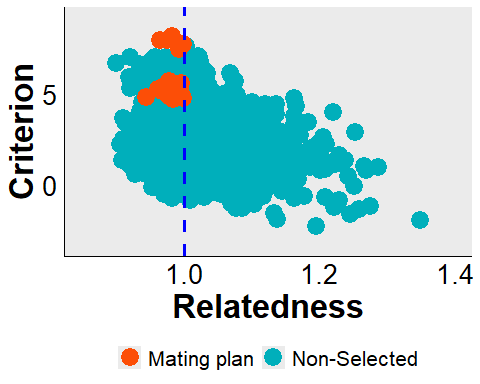

```r
# Plot
maxGainPlan[[3]]
```

## Optimization: Using cross total genetic value

Here, we will create a mating plan through an optimization based on the total genetic value for one trait controlled by additive and dominance effects, using molecular markers.

We need the crossing plan, with all individual candidates to parents. We may use the function `planCross()` for doing so. The parents are all individuals genotyped (*TargetPop*). We may choose which mate design we want (*MateDesign*). The upcoming step is to use the function `getTGV()` to predict the total genetic value for each cross in the cross plan, using the markers, markers’ effects, and the relationship matrix to generate the input for the new optimization function itself.

```r
require(SimpleMating)

# 1. Loading the data
data(generic_GenMap)
data(generic_Geno)
data(generic_MrkEffects)

# 2. Creating a relationship matrix based on markers
relMat <- (generic_Geno %*% t(generic_Geno)) / ncol(generic_Geno)

# 3. Assigning parents
Parents <- rownames(generic_Geno)

# 4. Creating the crossing plan
Cross_plan <- planCross(TargetPop = Parents,
                        MateDesign = "half")
```

```
#> Number of crosses generated: 4950
```

```r
# 5. Estimates the total genetic value for the progenies of each cross
total_gv <- getTGV(MatePlan = Cross_plan,
                   Markers = generic_Geno,
                   addEff = generic_MrkEffects[, 1],
                   domEff = generic_MrkEffects[, 3],
                   K = relMat,
                   ploidy = 2)
```

```
#> TGVs predicted for 4950 crosses.
```

```r
head(total_gv, 10)
```

```
#>    Parent1 Parent2       Y         K
#> 1    29121   29138 0.94021 1.1222222
#> 2    29121   29141 3.82345 0.9694444
#> 3    29121   29173 3.27528 0.9618056
#> 4    29121   29174 2.46291 0.9472222
#> 5    29121   29179 3.63474 0.9548611
#> 6    29121   29193 3.33305 1.0020833
#> 7    29121   29205 1.54588 1.0201389
#> 8    29121   29213 2.04343 1.0395833
#> 9    29121   29233 2.06714 1.0194444
#> 10   29121   29245 2.34731 0.9881944
```

The second part uses a criterion for each cross (total genetic value in this example) with a relationship matrix (based on markers in this example) and creates an optimum cross-selection-based mating plan. The idea is to restrict the levels of inbreeding, using the covariance in the individual-cross level, and maximize the criterion used (total genetic value in this example). There is needed to set the target number of crosses in the mating plan (*n.cross*), with the maximum and minimum number of crosses that each parent can be part of (*max.cross* and *min.cross*), together with the level of covariance between cross via relationship matrix for the restriction (*culling.pairwise.k*).

The output will be the mating plan based on the parameters before mentioned.

```r
# 1. Crosses selected
maxGainPlan <- selectCrosses(data = total_gv,
                             n.cross = 25,
                             max.cross = 10,
                             min.cross = 1,
                             culling.pairwise.k = 1.1)


# Crosses parameters
maxGainPlan[[1]]
```

```
#>   culling.pairwise.k target.Y  target.K
#> 1                1.1 5.929714 0.9994167
```

```r
# Mating Plan
maxGainPlan[[2]]
```

```
#>    Parent1 Parent2       Y         K
#> 1    29988   30069 7.60248 0.9819444
#> 2    30069   30010 7.47667 0.9750000
#> 3    30069   30098 7.36695 0.9645833
#> 4    30069   29577 7.21645 1.0034722
#> 5    30069   29766 7.20845 0.9979167
#> 6    30069   29779 6.92268 0.9923611
#> 7    30069   29732 6.60909 0.9736111
#> 8    30069   29593 6.55606 1.0222222
#> 9    30069   29765 6.53291 0.9569444
#> 10   30069   29776 6.50338 1.0041667
#> 11   29988   29593 5.79058 1.0680556
#> 12   29577   29141 5.45943 1.0013889
#> 13   29766   29577 5.45905 1.0722222
#> 14   29406   29577 5.39024 0.9951389
#> 15   29988   29577 5.31732 1.0236111
#> 16   29779   29193 5.26292 0.9777778
#> 17   30098   29577 5.24666 0.9833333
#> 18   29988   30098 5.16477 1.0756944
#> 19   29426   29577 5.15370 0.9611111
#> 20   29988   29805 5.09140 1.0027778
#> 21   29577   30010 5.04938 0.9708333
#> 22   29577   29975 4.99133 1.0256944
#> 23   29141   29574 4.97513 0.9694444
#> 24   29779   29141 4.96099 0.9736111
#> 25   29988   29406 4.93483 1.0125000
```

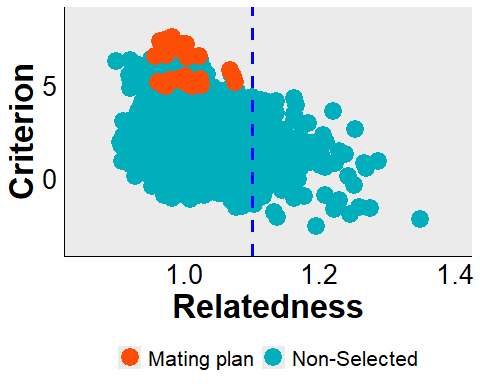

```r
# Plot
maxGainPlan[[3]]
```

## Optimization: Using the Mid-Parental Value

Here, we will create a mating plan through optimization based on the Mid-Parental Value for one additive trait using pedigree information.

We need the crossing plan, with all individual candidates to parents. We may use the function `planCross()` for doing so. The parents are all individuals genotyped (*TargetPop*). We may choose which mate design we want (*MateDesign*). Then, we need to organize the dataset for the predictions. The input to calculate the Mid-Parental Value is a two-column data frame, where in the first row we have the individual’s identification (same names that we find in the cross plan), and the criterion. By criterion, you can specify the estimated breeding value (EBV) or even the best linear unbiased prediction (BLUP) of each individual. This allows us to use this function for polyploid individuals, for example. In this case, we can make the predictions and input the values to calculate the expected Mid-Parental Value for each cross.

```r
require(SimpleMating)

# 1. Loading the information
data(generic_Pedigree)
data(generic_IndBLUP)
data(generic_Geno)

# 2. Using AGHMatrix to build the G matrix
AMat <- AGHmatrix::Amatrix(data = generic_Pedigree)
```

```
#> Verifying conflicting data...
#> Organizing data...
#> Your data was chronologically organized with success.
#> Constructing matrix A using ploidy = 2
#> Completed! Time = 0.0003333333  minutes
```

```r
# 3. Assigning parents
Parents <- rownames(generic_Geno)

# 4. Creating the mating plan
CrossPlan <- planCross(TargetPop = Parents,
                       MateDesign = "half")
```

```
#> Number of crosses generated: 4950
```

```r
# 5. Criterion
Crit <- data.frame(Id = generic_IndBLUP[,1],
                   Criterion = generic_IndBLUP[, 2])


# 6.Single trait mean parental average
ST_mpv <- getMPV(MatePlan = CrossPlan,
                 Criterion = Crit,
                 K = AMat)
```

```
#> 4950 possible crosses were predicted
```

```r
head(ST_mpv, 20)
```

```
#>    Parent1 Parent2        Y K
#> 1    29988   30069 175.1673 0
#> 2    30069   29406 173.9280 0
#> 3    30069   29551 169.9036 0
#> 4    30069   30098 169.8895 0
#> 5    30069   29768 169.8379 0
#> 6    30069   29766 169.4261 0
#> 7    30069   29426 169.2966 0
#> 8    29988   29406 169.0046 0
#> 9    30069   29497 168.9645 0
#> 10   30069   29898 168.8804 0
#> 11   30069   29577 168.2743 0
#> 12   30069   29760 168.2431 0
#> 13   30069   29791 168.1582 0
#> 14   30069   29372 167.7388 0
#> 15   30069   29975 167.4502 0
#> 16   30069   29529 167.2337 0
#> 17   30069   29601 167.1417 0
#> 18   30069   29141 167.0200 0
#> 19   30069   29121 166.8110 0
#> 20   30069   29792 166.7701 0
```

The second part uses a criterion for each cross (Mid-Parental Value in this example) with a relationship matrix (based on pedigree information in this example) and creates an optimum cross-selection-based mating plan. The idea is to restrict the levels of inbreeding, utilizing the covariance in the individual-cross level, and maximize the criterion used (Mid-Parental Value in this example). There is needed to set the target number of crosses in the mating plan (*n.cross*), with the maximum and minimum number of crosses that each parent can be part of (*max.cross* and *min.cross*), together with the level of covariance between cross via relationship matrix for the restriction (*culling.pairwise.k*).

The output will be the mating plan based on the parameters before mentioned.

```r
# 1. Crosses selected
maxGainPlan <- selectCrosses(data = ST_mpv,
                             n.cross = 25,
                             max.cross = 10,
                             min.cross = 1,
                             culling.pairwise.k = 0.21)

# Crosses parameters
maxGainPlan[[1]]
```

```
#>   culling.pairwise.k target.Y target.K
#> 1               0.21   166.72        0
```

```r
# Mating Plan
maxGainPlan[[2]]
```

```
#>    Parent1 Parent2        Y K
#> 1    29988   30069 175.1673 0
#> 2    30069   29406 173.9280 0
#> 3    30069   29551 169.9036 0
#> 4    30069   30098 169.8895 0
#> 5    30069   29768 169.8379 0
#> 6    30069   29766 169.4261 0
#> 7    30069   29426 169.2966 0
#> 8    29988   29406 169.0046 0
#> 9    30069   29497 168.9645 0
#> 10   30069   29898 168.8804 0
#> 11   30069   29577 168.2743 0
#> 12   29988   29551 164.9802 0
#> 13   29988   30098 164.9661 0
#> 14   29988   29768 164.9145 0
#> 15   29988   29766 164.5027 0
#> 16   29988   29426 164.3733 0
#> 17   29988   29497 164.0412 0
#> 18   29988   29898 163.9571 0
#> 19   29406   29551 163.7409 0
#> 20   29406   30098 163.7268 0
#> 21   29406   29768 163.6752 0
#> 22   29988   29577 163.3510 0
#> 23   29406   29766 163.2634 0
#> 24   29406   29426 163.1340 0
#> 25   29406   29497 162.8019 0
```

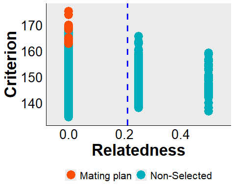

```r
# Plot
maxGainPlan[[3]]
```

## Optimization: Using the linkage disequilibrium to predicts the crosses variance

From the original proposition, a genetic map (the input in the Haldane function to estimate the recombination rates in the population) is required (Lehermeier et al. 2017) for the estimation of cross variance. In addition, it is not straightforward to have a genetic map that represents the target population under study. In this way, we replace the information of the matrix with the recombination frequencies between pairs of SNPs by the linkage disequilibrium (LD) matrix. It is known that the the LD varies from 0-1 in a population, being values close to an integer the recombination is low and when it is close to zero, the recombination frequency is high. Linkage disequilibrium can be estimated from a markers matrix (with or without phasing information). It was implemented in the function that estimates the usefulness (`getUsefA`, `getUsefAD`, `getUsefA_mt`, and `getUsefAD_mt`) the estimation of the cross variance and, ultimately, the cross usefulness by using the LD matrix. By doing so, the user may give the LD matrix in the argument `linkDes` and give the chromosome and the SNP id in the argument `Map.In`.

```r
require(SimpleMating)

# 1. Load data
data(lines_Geno)

# 2. Assuming a naive LD measure
linkageDes <- (t(lines_Geno) %*% lines_Geno)/(ncol(lines_Geno))

# 3. Creating relationship matrix based on markers
relMat <- (lines_Geno %*% t(lines_Geno)) / ncol(lines_Geno)

# 4. Assigning the parents
Parents <- rownames(lines_Geno)

# 5. Creating the crossing plan
Cross_plan <- planCross(TargetPop = Parents,
                        MateDesign = "half")
```

```
#> Number of crosses generated: 4950
```

```r
# 6. Information on the SNPs
mapInfo = lines_GenMap[,c(1,3)]

# 7.  Usefulness of trait number 1 (DH)
usef_add <- getUsefA(MatePlan = Cross_plan,
                     Markers = lines_Geno,
                     addEff = lines_addEffects[, 1],
                     Map.In = mapInfo,
                     linkDes = linkageDes,
                     K = relMat,
                     propSel = 0.05,
                     Type = "DH",
                     Generation = 1)
```

```
#> Usefulness predicted for 4950 crosses.
```

```r
head(usef_add[[1]], 10)
```

```
#>    Cross.ID Parent1 Parent2    Mean  Variance        sd Usefulness
#> 1     G1_G2      G1      G2 4.51880 0.1205174 0.3471562    5.23488
#> 2     G2_G3      G2      G3 4.01124 0.3289240 0.5735190    5.19424
#> 3     G1_G3      G1      G3 4.10644 0.2206587 0.4697432    5.07539
#> 4     G1_G4      G1      G4 4.27818 0.1269868 0.3563520    5.01323
#> 5     G2_G4      G2      G4 4.18298 0.1609132 0.4011399    5.01042
#> 6     G3_G4      G3      G4 3.77061 0.3408383 0.5838136    4.97485
#> 7     G1_G5      G1      G5 3.48462 0.3643654 0.6036268    4.72973
#> 8     G2_G5      G2      G5 3.38943 0.4088559 0.6394184    4.70837
#> 9     G1_G9      G1      G9 3.04164 0.6263750 0.7914386    4.67415
#> 10   G1_G24      G1     G24 3.09747 0.5749812 0.7582751    4.66157
```

## Thinning by relatedness: How to speed up prediction

The *relateThinning()* is an optional step and it will increase the efficiency of the prediction by cutting individuals by relatedness and, consequently, decrease the time for the prediction of usefulness and cross-optimization. It selects the top individuals within a family by the relatedness `threshold`. For example, if `max.per.cluster=4` and `threshold = 0.1` the algorithm will identify all groups of individuals that shared more than 0.1 in the relationship matrix and select the top 4 individuals with the highest criterion to be used as possible parents in the mating plan. Besides those arguments, we need to give to the function the relationship matrix (`K`) between the parents. It could be the relationship matrix based on markers information (G) or based on pedigree information (A). In addition, a `criterion` should be added, such as the estimated breeding value, total breeding value, or the BLUP of the candidates (not the cross as before).

```r
require(SimpleMating)

# 1. Loading the data
data(generic_Geno)
data(generic_IndBLUP)

# 2. Creating relationship matrix based on markers
ScaledMarkers = scale(generic_Geno, scale = FALSE)
relMat <- (ScaledMarkers %*% t(ScaledMarkers)) / ncol(ScaledMarkers)

# 3. Criterion for the trait
Crit <- data.frame(Id = rownames(generic_IndBLUP),
                   Criterion = generic_IndBLUP[, 2]) # trait number one

# 4. Trimming by relatedness
keep <- relateThinning(K = relMat,
                      Criterion = Crit,
                      threshold=0.1,
                      max.per.cluster=4)
```

```
#> 93 genotypes kept out of 100
```

```r
# 5. Crossing plan using the argument Indiv2keep
plan <- planCross(TargetPop = colnames(relMat),
                 MateDesign = 'half',
                 Indiv2keep = keep)
```

```
#> Number of crosses generated: 4278
```

As a result, we kept 93 individuals out of 100 individuals. In such case, we will predict usefulness or mean parental average/total genetic value for 4278 crosses instead of 4950 crosses (the number of crosses resulted from the matching of 100 individuals). When we have a large number of parents, such as 2000 individuals as candidates to parents, the function can be used to decrease the time for prediction and optimization.

## Bibliography

Akdemir & Sánchez (2016). Efficient breeding by genomic mating. Frontiers in Genetics. https://doi.org/10.3389/fgene.2016.00210  
Allier et al. (2019). Usefulness criterion and post-selection parental contributions in multi-parental crosses: Application to polygenic trait introgression. G3: Genes, Genomes, Genetics. https://doi.org/10.1534/g3.119.400129  
Bonk et al. (2016). Mendelian sampling covariability of marker effects and genetic values. Genetics Selection Evolution. https://gsejournal.biomedcentral.com/articles/10.1186/s12711-016-0214-0  
Lehermeier (2017). Genetic gain increases by applying the usefulness criterion with improved variance prediction in selection of crosses. Genetics. https://doi.org/10.1534/genetics.117.300403  
Schnell & Utz (1976). F1 Leistung und Elternwahl in der Zuchtung von Selbstbefruchtern. Ber Arbeitstag Arbeitsgem Saatzuchtleiter.  
Toro & Varona (2010). A note on mate allocation for dominance handling in genomic selection. Genetics Selection Evolution. https://doi.org/10.1186/1297-9686-42-33  
Varona et al. (2018). Non-additive effects in genomic selection. Frontiers in Genetics. https://doi.org/10.3389/fgene.2018.00078  
Wolfe et al. (2021). Genomic mating in outbred species: Predicting cross usefulness with additive and total genetic covariance matrices. Genetics. https://doi.org/10.1093/genetics/iyab122